# Animating taichi diagrams

Youzhi Yu University of Chicago

> **Every animation on this page is really rendered when the vignette is built.** Before 0.3.0 the `animate()` calls here were commented out for CI, which is how a bug that collapsed every transition to a single frame went unnoticed through two releases. See `NEWS.md`.

## Why animate?

A taichi (yin-yang) symbol is *cyclical*, so motion is unusually on-brand for this geom. Instead of forcing a third variable (e.g. `week`) onto the x-axis and shrinking every glyph, we can turn it into an **animation frame**. Each frame is then a clean `category` x `state` grid of large, readable taichi.

This vignette shows how to combine `geom_taichi()` with [gganimate](https://gganimate.com). `gganimate` is a *Suggested* dependency; install it with `install.packages("gganimate")` if you have not already.

```r
library(ggplot2)
library(ggtaichi)
library(gganimate)
```

## How `geom_taichi()` composes with gganimate

`geom_taichi()` returns a pair of layers separated by `ggnewscale::new_scale_fill()`, so each fish keeps its own fill scale and legend. gganimate works at the *layer* level: it splits every layer’s data by the transition variable and builds one frame per state. Because the two fish layers are ordinary `ggplot2` layers, gganimate treats them independently and the two fill scales continue to apply frame-by-frame. In short: **the ggnewscale layer stack composes cleanly with gganimate**, so no special wrapper is needed. (This is not just theory: every recipe below has been rendered frame-by-frame against gganimate 1.0.11, with both legends and the per-fish fills intact in every frame.)

## Animating over a third variable

Use `transition_states()` when the frame variable is discrete (e.g. week number), or `transition_time()` when it is a continuous time. Both drive the underlying fish layers. The bundled `states_tg` data is a perfect showcase: instead of squeezing its 31 weeks onto the x-axis, keep a `category` x `state` grid of large glyphs and let the weeks play out as frames. Because the fills are continuous, `tweenr` interpolates the values smoothly between consecutive weeks.

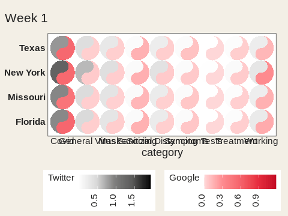

```r
states_small <- subset(states_tg, week <= 8)

p <- ggplot(states_small, aes(x = category, y = state)) +
  geom_taichi(yin = Twitter, yang = Google) +
  theme_taichi() +
  labs(title = "Week {closest_state}") +
  transition_states(week, transition_length = 1, state_length = 1)

show_animation(p, nframes = 24)
```

```r
# and to save it:  anim_save("taichi.gif", p)
```

## Keeping glyphs round

Taichi symbols are always drawn round (they are sized in square units, like `grid::circleGrob()`), but `coord_fixed()` keeps the *cells* square too, so the glyphs fill them evenly. Match the animation dimensions to the grid:

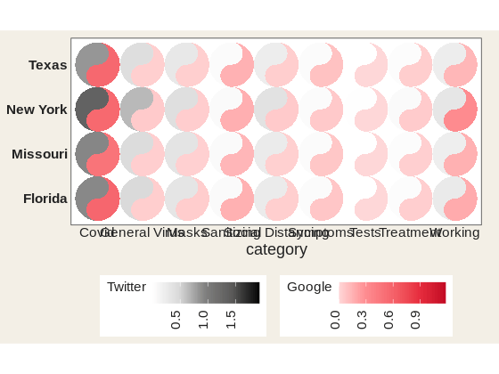

```r
p_fixed <- ggplot(states_small, aes(x = category, y = state)) +
  geom_taichi(yin = Twitter, yang = Google) +
  coord_fixed() +
  theme_taichi() +
  transition_states(week, transition_length = 1, state_length = 1)

show_animation(p_fixed, nframes = 24, width = 560, height = 420)
```

## Spin animation

With the `angle` argument (see `?geom_taichi`) you can rotate each glyph. Mapping `angle` to an expression of the frame variable and animating produces the iconic “turning taichi”, and with `eyes = TRUE` each eye rides around in its own fish’s head:

[figure not shown]

```r
spin <- data.frame(
  x = 1, y = 1, yin = 5, yang = 5,
  frame = 1:36
)

p_spin <- ggplot(spin, aes(x, y)) +
  geom_taichi(yin = yin, yang = yang, angle = frame * 10,
              eyes = TRUE) +
  coord_fixed() +
  theme_taichi() +
  transition_states(frame, transition_length = 0, state_length = 1)

show_animation(p_spin, nframes = 36, fps = 12, width = 300, height = 300)
```

Note the `state_length = 1` with `transition_length = 0`: each frame *is* a state, so the rotation advances in crisp steps (at least one of the two lengths must be positive, or gganimate cannot allocate frames).

A cell that appears or disappears between states pops in and out whole. `enter_grow()` and `exit_shrink()` have no visible effect, because they scale a size the glyph does not have, and `enter_fade()` and `enter_recolour()` stop with an error on any plot that uses a `ggnewscale::new_scale_fill()` break, which every `geom_taichi()` plot does. `enter_drift()` does move an entering glyph in.

## Export helpers

`gganimate::anim_save()` writes the animation to a file. For MP4 output use `ffmpeg_renderer()` (requires a system `ffmpeg`); for GIF use `gifski_renderer()` (requires the `gifski` package). Aim for 10–15 fps and enough frames that the motion is smooth; `coord_fixed()` keeps every glyph round in the rendered video.